# 2016 Presidential Campaign Finance by Megan O’Neil

I am analyzing presidential campaign finance for the 2016 election. I am interested in looking at contributions from around the US.

The ‘us’ datafile contains all campaign contributions in the US for the 2016 presidential election. It contains 7,344,719 observations/pieces of data. I’m going to run my analysis on a sample of 10,000 observations.

```
## [1] "C:/Dropbox/Pers/Courses/Nanodegree/P4/FinalProject"
```

```
## 'data.frame':    7344719 obs. of  19 variables:
##  $ cmte_id          : Factor w/ 26 levels "C00458844","C00496034",..: 1 1 1 1 1 1 1 1 1 1 ...
##  $ cand_id          : Factor w/ 25 levels "P00003392","P20002671",..: 11 11 11 11 11 11 11 11 11 11 ...
##  $ cand_nm          : Factor w/ 25 levels "Bush, Jeb","Carson, Benjamin S.",..: 19 19 19 19 19 19 19 19 19 19 ...
##  $ contbr_nm        : Factor w/ 1352948 levels "'CALL, ALLAN",..: 109745 308891 207235 309567 1046542 1046542 522178 207235 998212 522178 ...
##  $ contbr_city      : Factor w/ 25961 levels "","'CALLAHAN",..: 24516 1013 5985 756 756 756 756 5985 756 756 ...
##  $ contbr_st        : Factor w/ 115 levels "20","30","AA",..: 1 2 5 5 5 5 5 5 5 5 ...
##  $ contbr_zip       : Factor w/ 871293 levels "",".","`1136",..: 871228 871232 92700 92660 92444 92444 92444 92700 152 92440 ...
##  $ contbr_employer  : Factor w/ 392185 levels "","''I LIKE COMICS''",..: 328220 230318 99351 101117 366207 366207 167611 99351 141958 286836 ...
##  $ contbr_occupation: Factor w/ 125504 levels "","''''FOR HIRE'''' DRIVER",..: 76234 85057 118479 112965 80842 80842 55604 118479 8049 95139 ...
##  $ contb_receipt_amt: num  175 25 100 500 200 ...
##  $ contb_receipt_dt : Factor w/ 816 levels "01-APR-15","01-APR-16",..: 381 408 508 677 251 200 705 140 460 770 ...
##  $ receipt_desc     : Factor w/ 203 levels ""," SEE REATTRIBUTION",..: 1 1 1 1 1 1 1 1 1 1 ...
##  $ memo_cd          : Factor w/ 2 levels "","X": 1 1 1 1 1 1 1 1 1 1 ...
##  $ memo_text        : Factor w/ 1714 levels ""," SEE REATTRIBUTION",..: 1 989 1 1 1 1 1 1 989 1 ...
##  $ form_tp          : Factor w/ 3 levels "SA17A","SA18",..: 1 1 1 1 1 1 1 1 1 1 ...
##  $ file_num         : int  1082559 1082559 1056862 1029436 1082559 1082559 1029436 1056862 1082559 1047126 ...
##  $ tran_id          : Factor w/ 7194803 levels "A0000FD2A304E432AAD5",..: 3662927 3663652 3571641 4126697 3608114 3605468 4140202 3641793 3663738 4176451 ...
##  $ election_tp      : Factor w/ 10 levels "","G2015","G2016",..: 7 7 7 7 7 7 7 7 7 7 ...
##  $ dummy            : logi  NA NA NA NA NA NA ...
```

```r
set.seed(1000)
us_samp <- us[sample(1:length(us$cand_id), 10000), ]
#str(us_samp)
us_samp <- us_samp[, !(colnames(us_samp) == 'dummy')]
str(us_samp)
```

```
## 'data.frame':    10000 obs. of  18 variables:
##  $ cmte_id          : Factor w/ 26 levels "C00458844","C00496034",..: 7 8 5 8 7 5 8 7 7 7 ...
##  $ cand_id          : Factor w/ 25 levels "P00003392","P20002671",..: 1 12 10 12 1 10 12 1 1 1 ...
##  $ cand_nm          : Factor w/ 25 levels "Bush, Jeb","Carson, Benjamin S.",..: 4 20 5 20 4 5 20 4 4 4 ...
##  $ contbr_nm        : Factor w/ 1352948 levels "'CALL, ALLAN",..: 338441 1093456 608606 437463 1903 1085227 451435 845869 1105237 808529 ...
##  $ contbr_city      : Factor w/ 25961 levels "","'CALLAHAN",..: 16793 20047 5373 17006 2787 4748 1247 2969 3190 24516 ...
##  $ contbr_st        : Factor w/ 115 levels "20","30","AA",..: 47 59 101 31 81 34 55 110 20 24 ...
##  $ contbr_zip       : Factor w/ 871293 levels "",".","`1136",..: 515437 505816 551154 313892 179801 287714 224857 851857 736431 198552 ...
##  $ contbr_employer  : Factor w/ 392185 levels "","''I LIKE COMICS''",..: 286836 40856 180635 243294 286836 379953 229068 41145 87646 94647 ...
##  $ contbr_occupation: Factor w/ 125504 levels "","''''FOR HIRE'''' DRIVER",..: 112965 98027 8049 73089 858 64615 6776 103579 96288 4179 ...
##  $ contb_receipt_amt: num  59.4 27 2700 15 50 ...
##  $ contb_receipt_dt : Factor w/ 816 levels "01-APR-15","01-APR-16",..: 664 451 451 338 27 9 134 688 485 496 ...
##  $ receipt_desc     : Factor w/ 203 levels ""," SEE REATTRIBUTION",..: 1 1 145 1 1 1 1 1 1 1 ...
##  $ memo_cd          : Factor w/ 2 levels "","X": 2 1 2 1 2 1 1 1 2 1 ...
##  $ memo_text        : Factor w/ 1714 levels ""," SEE REATTRIBUTION",..: 465 324 1185 324 465 1 324 1 613 1 ...
##  $ form_tp          : Factor w/ 3 levels "SA17A","SA18",..: 2 1 1 1 2 1 1 1 1 1 ...
##  $ file_num         : int  1112134 1077916 1071498 1079445 1112134 1071498 1079445 1133832 1126762 1119042 ...
##  $ tran_id          : Factor w/ 7194803 levels "A0000FD2A304E432AAD5",..: 653784 5680515 3747681 6498691 583455 3785103 6381171 1249000 3221321 993345 ...
##  $ election_tp      : Factor w/ 10 levels "","G2015","G2016",..: 3 7 3 7 3 7 7 3 7 3 ...
```

# Univariate Plots Section

## Contribution amount

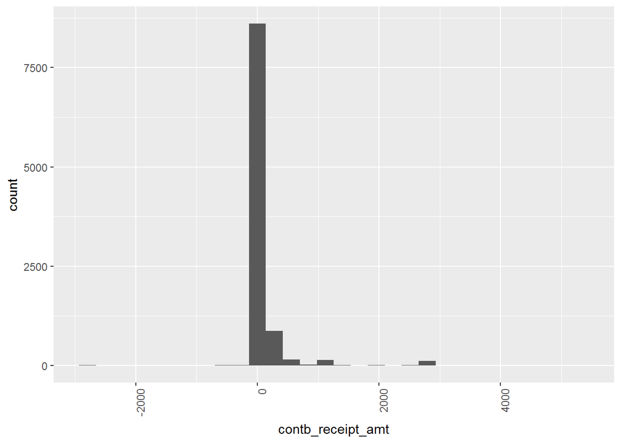

There are negative contributions, I am going to look at these, then remove them from a clean dataset.

```r
summary(us_samp$contb_receipt_amt)
```

```
##    Min. 1st Qu.  Median    Mean 3rd Qu.    Max.
## -2700.0    15.0    27.0   113.9    91.0  5400.0
```

```r
summary(subset(us_samp$contb_receipt_amt,us_samp$contb_receipt_amt < 0))
```

```
##    Min. 1st Qu.  Median    Mean 3rd Qu.    Max.
## -2700.0  -500.0  -100.0  -517.6   -25.0    -5.0
```

```r
nrow(subset(us_samp,us_samp$contb_receipt_amt < 0))
```

```
## [1] 98
```

```r
# removing negative contributions (98):
us_samp.clean <- subset(us_samp,us_samp$contb_receipt_amt > 0)

summary(us_samp.clean$contb_receipt_amt)
```

```
##    Min. 1st Qu.  Median    Mean 3rd Qu.    Max.
##    0.44   16.00   28.00  120.10  100.00 5400.00
```

The median contribution amount is $28, mean of $120 and max of $5400. That max is interesting since the maximum allowed for an individual to make to a candidate is $2,700 (source: http://www.fec.gov/info/contriblimitschart1516.pdf). I’m goin to look at these a bit more.

```r
#View(head(us_samp.clean[with(us_samp.clean, order(-contb_receipt_amt)), ], 20))
```

Well, there are 3 contributions for $5400, one for $5k, one for $4k, and a number for $2700 in this sample. I am going to leave them, apparently these folks got a workaround the limit.

Now I’ll look at the distribution of this ‘cleaner’ dataset, without the negative contributions but including the high ones.

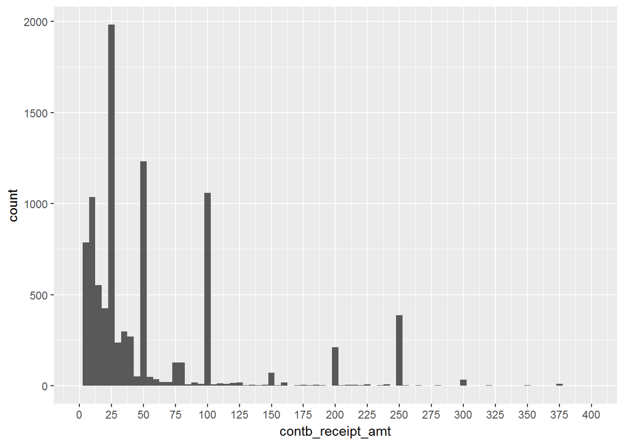

```r
ggplot(aes(x = contb_receipt_amt), data = us_samp.clean) +
    geom_histogram(binwidth = 5) +
    scale_x_continuous(limits = c(0,quantile(us_samp.clean$contb_receipt_amt, .95)),
                       breaks = seq(0,400,25))
```

The distribution of contribution amounts is positively skewed. Let’s try a log-10 transformation of the contribution amount.

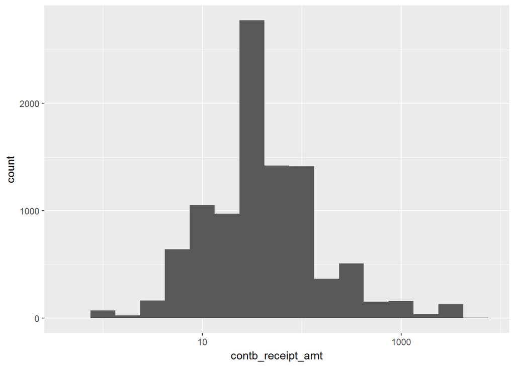

```r
ggplot(aes(x = contb_receipt_amt), data = us_samp.clean) +
    geom_histogram(binwidth = .25) +
    scale_x_log10()
```

This revealed a much more normal distribution.

### Candidate

Let’s review by candidate.

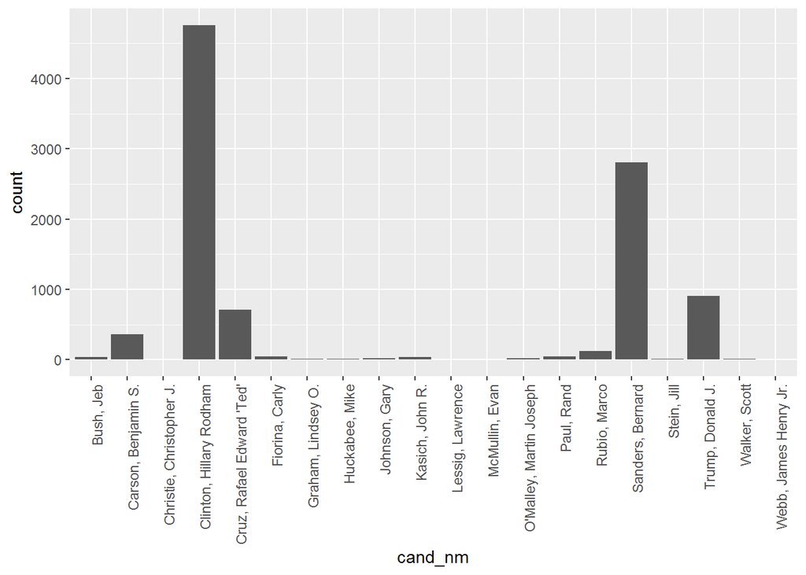

```r
qplot(x = cand_nm, data = us_samp.clean) +
    theme(axis.text.x = element_text(angle = 90, hjust = 1))
```

Clinton had the largest number of donations, follwed by Sanders, Trump, then Cruz.

Let’s look at the primaries only. I’m going to proxy the primaries by including up to the date that Sanders officially dropped out of the race, according to CNN, on July 11th, 2016. (CNN: http://www.cnn.com/2016/07/11/politics/hillary-clinton-bernie-sanders/)

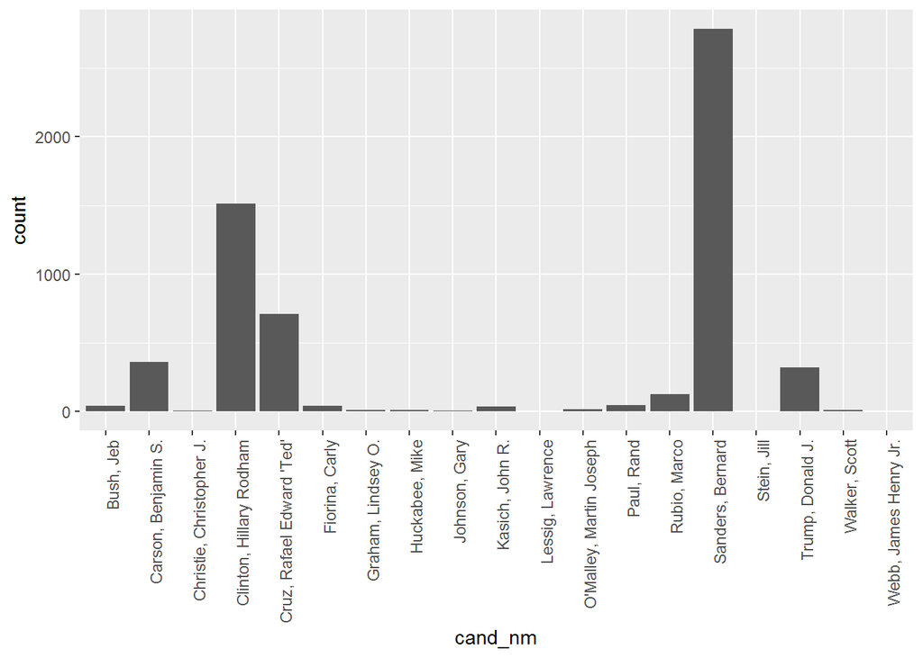

```r
# Convert contb_receipt_dt to date format
us_samp.clean <- mutate(us_samp.clean, contb_receipt_dt = dmy(contb_receipt_dt))
# Reference for dmy: http://stackoverflow.com/questions/21211285/converting-factor-to-date-in-r
# Reference for mutate: http://stackoverflow.com/questions/33408636/convert-column-in-data-frame-to-date

sanders_drop <- as.Date("2016-07-11")

#Subset dataset to include contributions up to last Bernie contribution
primaries <- us_samp.clean[which(us_samp.clean$contb_receipt_dt <= sanders_drop),]

# Test: #max(primaries$contb_receipt_dt)

# Plot for primaries
qplot(x = cand_nm, data = primaries) +
    theme(axis.text.x = element_text(angle = 90, hjust = 1))
```

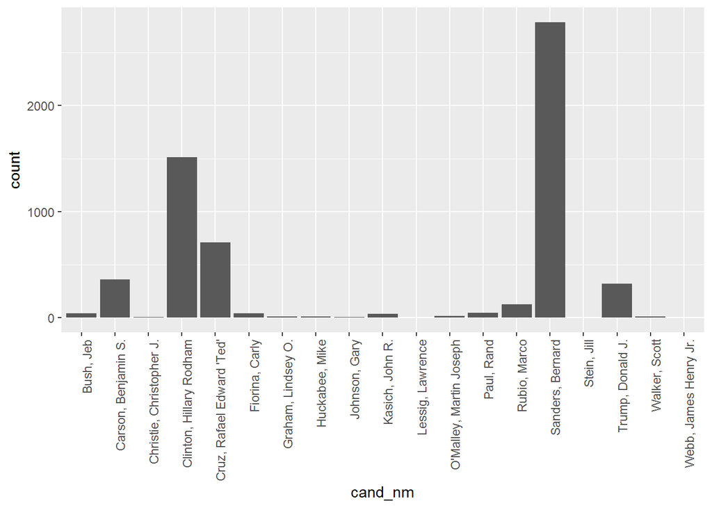

```r
ggplot(data = primaries, aes(x = cand_nm))+
    geom_bar()+
    theme(axis.text.x = element_text(angle = 90, hjust = 1))
```

The Bern’s ahead by a landslide.

## Political party

I want to add political party, which I think may have an effect on contribution size.

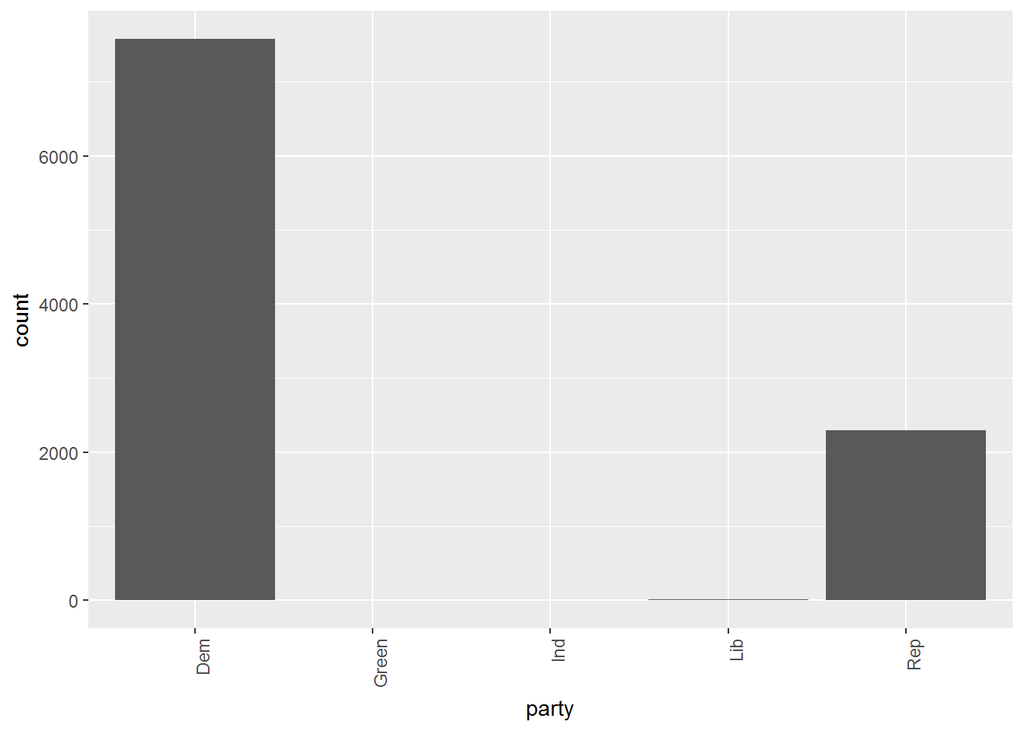

```r
# Create dataframe of candidate and political party
cand_list <- unique(us_samp.clean$cand_nm)
parties <- c('Dem', 'Dem', 'Rep', 'Rep', 'Rep','Rep','Rep','Rep','Dem','Rep','Rep','Rep',
          'Dem', 'Rep', 'Green', 'Rep', 'Rep', 'Lib','Ind', 'Dem')

cand_party <- data.frame(cand_list, parties)
names(cand_party) <- c('cand_nm', 'party')
#View(cand_party)

# Merge with broader dataframe
us_samp.clean <- merge(us_samp.clean, cand_party, by = "cand_nm")
#View(us_samp.clean)

# Plot for number of contributions by political party
qplot(x = party, data = us_samp.clean) +
    theme(axis.text.x = element_text(angle = 90, hjust = 1))
```

The democrats received by far the most campaign contributions, more than double that of Republicans. (Actual counts here are not meaningful as this is a sample.) The numbers of contributions to the other party categories, Green, Libertarian, and Independent, are negligible in comparison.

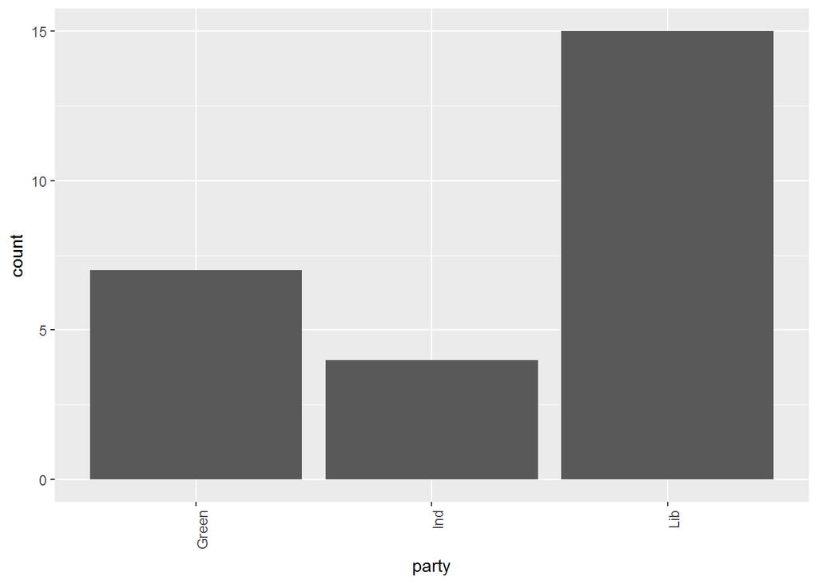

```r
qplot(x = party, data = us_samp.clean[which(us_samp.clean$party == 'Green' |
                                                us_samp.clean$party == 'Ind' |
                                                us_samp.clean$party == 'Lib'), ]) +
    theme(axis.text.x = element_text(angle = 90, hjust = 1))
```

Within the smaller parties, Libertarians were highest, followed by Green, followed by Independent. There was only one candidate in this sample for each of those parties: Jill Stein (Green), Evan McMullin (Independent), and Gary Johnson (Libertarian).

## State

I am interested in both the contributions by state and also contributions per capita by state. As such I’ll want to add in state population at some point, so I’ll do that now. I also noticed there are some weird state abbreviations in here, so I’ll take a look and remove the weird ones.

```r
# State population data from census: https://factfinder.census.gov/faces/tableservices/jsf/pages/productview.xhtml?pid=PEP_2015_PEPANNRES&src=pt
## Two header rows, skip one row
pop <- read.csv("PEP_2015_PEPANNRES_with_ann.csv",
                         header=TRUE,  skip=1)
# Keep only 2015 and rename header.
#names(pop)
pop1 <- pop[,c(3,11)]
names(pop1) <- c("State","pop2015")

#Dataset with states and abbreviations:
# http://www.fonz.net/blog/archives/2008/04/06/csv-of-states-and-state-abbreviations/
states <- read.csv("states.csv")
#View(states)

# Merge & rename abbreviated state column
pop.state <- merge(pop1, states, by = "State")
colnames(pop.state)[colnames(pop.state) == 'Abbreviation'] <- 'contbr_st'
pop.state$pop.hundthou <- pop.state$pop2015/100000
#View(pop.state)

# Now I want to see if there are any weird states in our us sample
states_all <- unique(us_samp.clean$contbr_st)
us_states <- pop.state$contbr_st
bad_states <- setdiff(states_all, us_states)
    # These are not US states, I'm going to remove them from our clean dataset.

us_samp.clean <- subset(us_samp.clean, !(contbr_st %in% bad_states))

# Merge datasets - us clean sample with pop.state
us_samp.clean <- merge(us_samp.clean, pop.state, by = 'contbr_st')
```

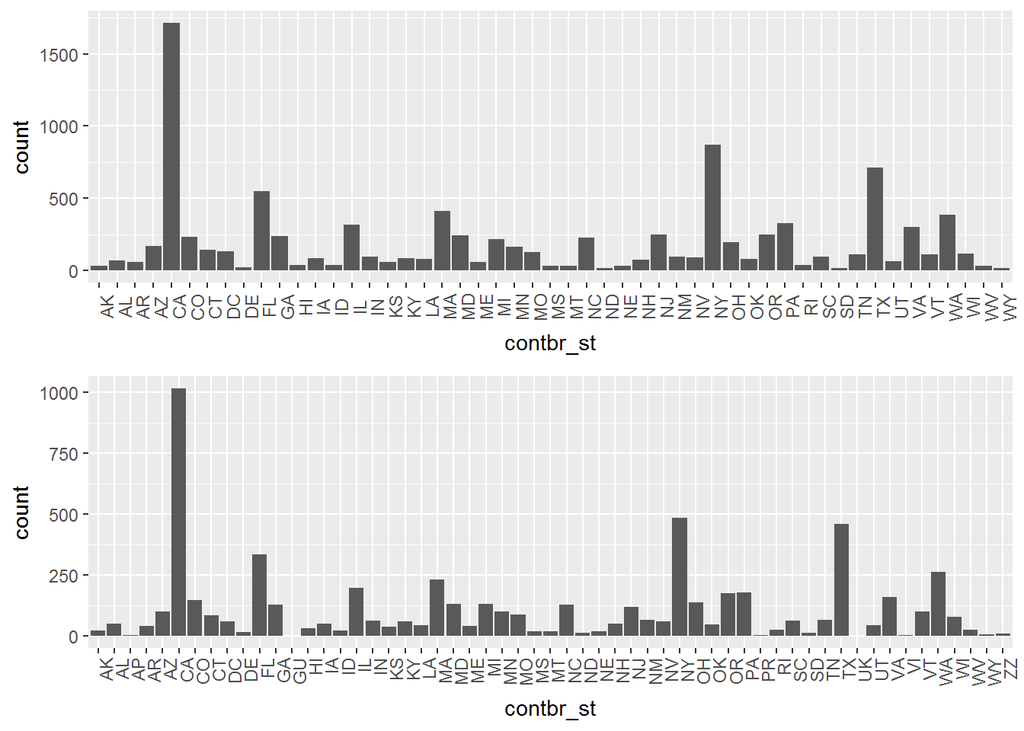

```r
states_count <- ggplot(aes(x = contbr_st), data = us_samp.clean) +
    geom_bar() +
    theme(axis.text.x = element_text(angle = 90))

#table(us_samp.clean$contbr_st)
# For primaries?
primary_states_count <- ggplot(data = primaries, aes(x = contbr_st))+
    geom_bar()+
    theme(axis.text.x = element_text(angle = 90, hjust = 1))

grid.arrange(states_count, primary_states_count)
```

The states with the highest contributions were California, New York, and Texas. Those are also the states with the highest population, so I will be interested to look at per capita rates of giving for each state. But that’s later on when I transform the datasets!

There is not much if any discernible difference in the distribution of contributions among states between the primaries and the overall election cycle, other than the actual amount of contributions. Makes sense.

## Occupation

```r
length(unique(us_samp.clean$contbr_occupation))
```

```
## [1] 2397
```

At over 2,000 unique occupations, that’s too many to plot! I have enough to look at otherwise.

## Contribution date

```r
summary( us_samp.clean$contb_receipt_dt)
```

```
##         Min.      1st Qu.       Median         Mean      3rd Qu.
## "2014-12-23" "2016-03-01" "2016-05-24" "2016-05-17" "2016-08-31"
##         Max.
## "2016-11-21"
```

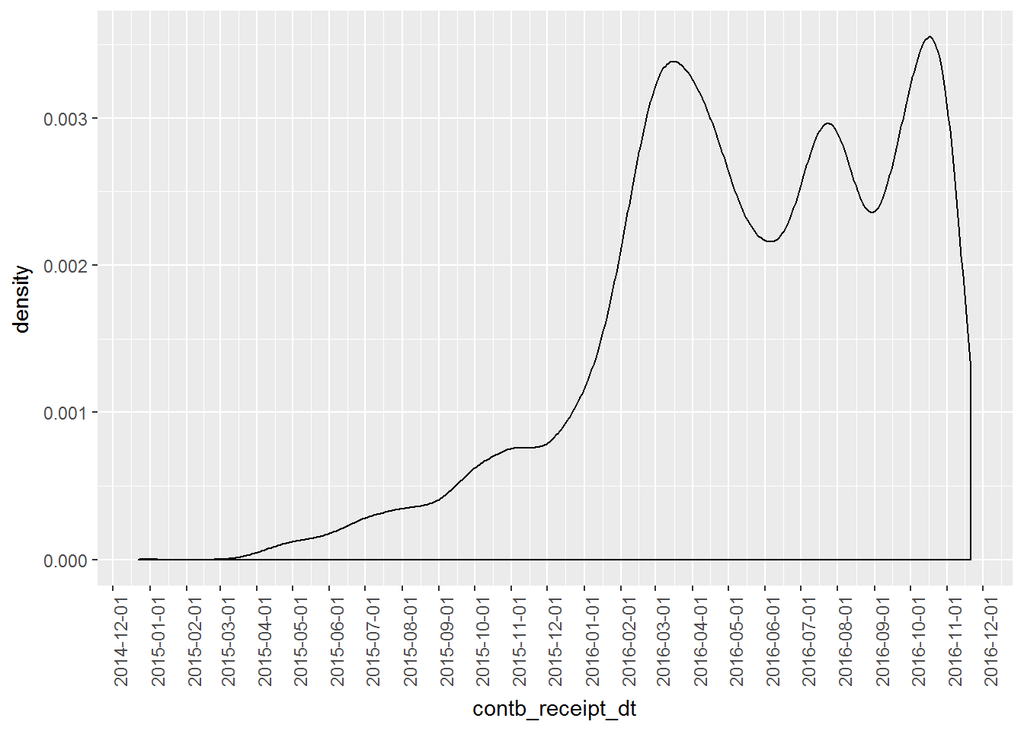

```r
# First creating density plots
contb_dt_density <- ggplot(data = us_samp.clean, aes(x = contb_receipt_dt)) +
    geom_density()+
    scale_x_date(breaks = date_breaks("month")) +
    theme(axis.text.x = element_text(angle = 90))
#Reference: http://docs.ggplot2.org/0.9.3.1/scale_date.html
# Reference: https://discussions.udacity.com/t/financial-contributions-data-gender-political-party-and-location/194785/14

contb_dt_density
```

# Univariate Analysis

### What is the structure of your dataset?

In the full US dataset, there are 7,344,719 contributions. I am interested in looking at the distribution of contributions across all 50 states, but realize the limitations of my computer in working with such a large dataset! So I took a sample of 10,000 contributions, ‘us_samp’.

The dataset has 18 variables: - 15 factor variables (none are ordered): cmte_id, cand_id, cand_nm, contrb_nm, contbr_city, contbr_st, contbr_zip, contbr_employer, contbr_occupation, receipt_desc, memo_cd, memo_text, form_tp, file_num, tran_id, election_tp. - 1 date variable: contb_receipt_dt (this was originally a factor variable but I converted it) - 1 integer: file_num - 1 number: contb_receipt_amt

### What is/are the main feature(s) of interest in your dataset?

I am most interested in the variables pertaining to candidate name and contribution receipt amount. I am interested in viewing the number and size of contributions that candidates received.

### What other features in the dataset do you think will help support your investigation into your feature(s) of interest?

Other factors that contribute to the number and size of contributions to each candidate include: - contributor’s state - contribution receipt date - candidate’s political party

### Did you create any new variables from existing variables in the dataset?

I created two variables: - party - for the political party of the candidate. - population - for the state population in 2015, in order to determine contributions per capita by state.

### Of the features you investigated, were there any unusual distributions? Did you perform any operations on the data to tidy, adjust, or change the form of the data? If so, why did you do this?

I log transformed the right skewed contribution amount distributions. The transformed distribution appears more normal, peaking at around $30.

The contribution date was the only other non-categorical variable, but I did not perform a transformation because these are dates, not numerical values, so a log or square transformation, are not appropriate.

# Bivariate & Multivariate Plots Section

I wanted to start with ggpairs to plot every variable against each other. I would have liked to use ggpairs but this analysis is challenging because all but 3 variables are categorical with more than 15 factors, which is the limit for ggpairs.

I’ve combined bivariate and multivariate because once I start looking at relationships between variables, it is easy and helpful to add additional variables in to review.

## Donations over time, lines for each party

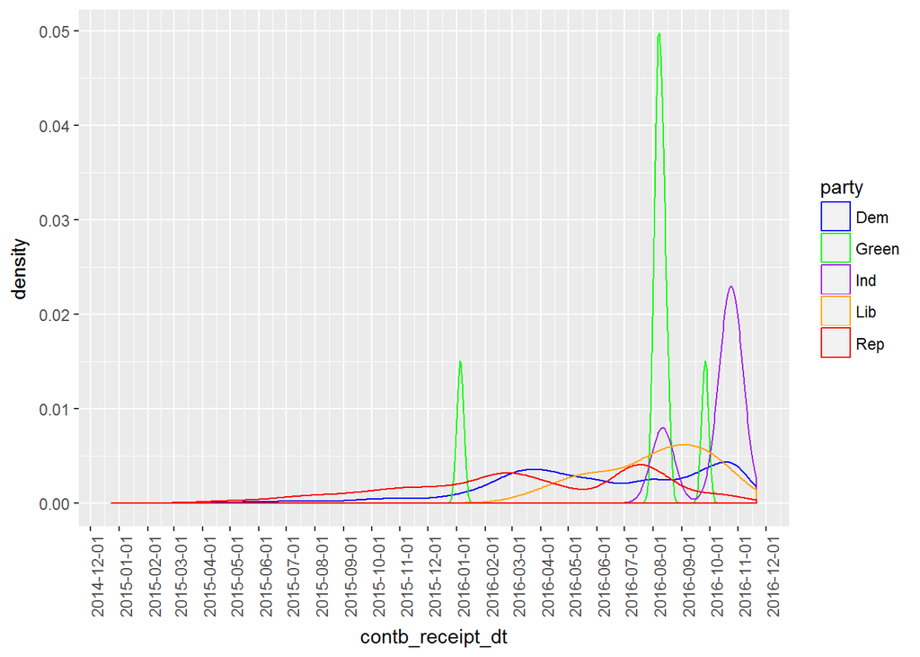

```r
ggplot(data = us_samp.clean, aes(x = contb_receipt_dt, color = party)) +
    geom_density()+
    scale_color_manual(values=c("blue", "green", "purple", " orange", "red"))+
    scale_x_date(breaks = date_breaks("month")) +
    theme(axis.text.x = element_text(angle = 90))
```

```r
# Reference: manually defined palettes: http://www.cookbook-r.com/Graphs/Colors_(ggplot2)/
```

The density plot is interesting becuase it shows relative density of contributions by each party. So the Green party has a much more distinct line because there were far fewer contributions overall than for the Republican and Democratic party, so the density plot is affected by one or two donations, in this sample.

Now I want to demonstrate total contributions over time for each party (rather than density of contributions), with lines included for when the second-to-last candidate in the Republican and Democratic primaries dropped out (Cruz and Sanders respectively). Given the small number of contributions for Green, Libertarian, and Independent parties, let’s just use Dems and Repubs.

```r
us_samp.by_date.party <- us_samp.clean %>%
    group_by(contb_receipt_dt, party) %>%
    summarise(mean_contb = mean(contb_receipt_amt),
              median_contb = median(contb_receipt_amt),
              n = n()) %>%
    arrange(contb_receipt_dt, party)

nrow(us_samp.by_date.party[which(us_samp.by_date.party$party == 'Green' |
                                     us_samp.by_date.party$party == 'Ind' |
                                     us_samp.by_date.party$party == 'Lib'),])
```

```
## [1] 23
```

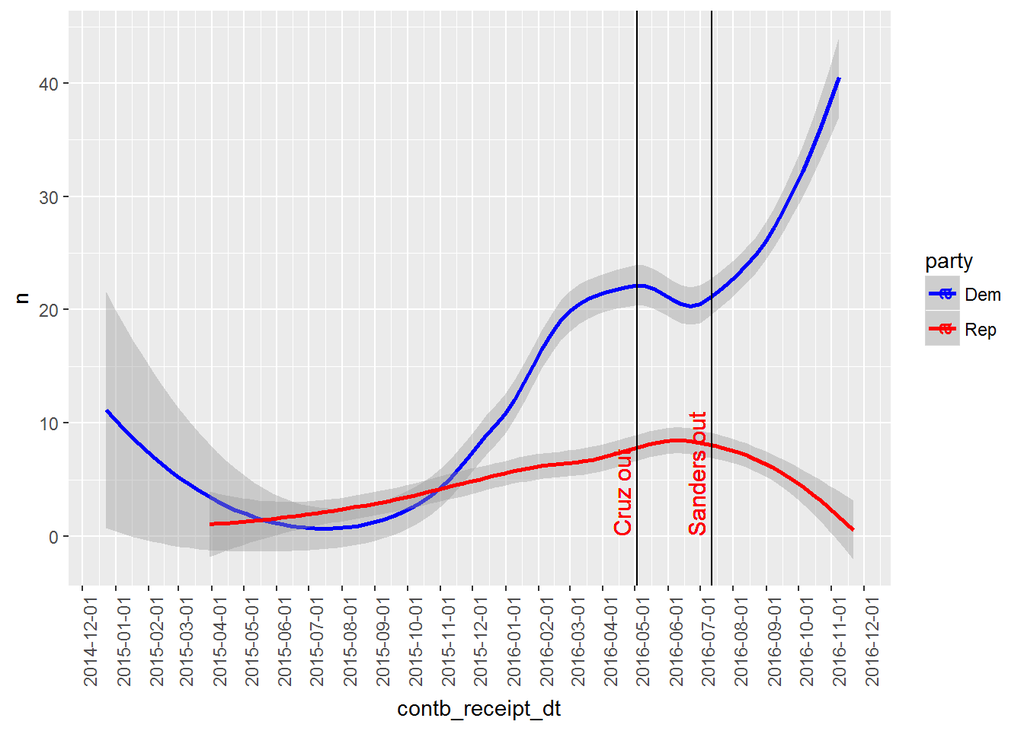

```r
ggplot(data = us_samp.by_date.party[which(us_samp.by_date.party$party == 'Dem' |
                                              us_samp.by_date.party$party == 'Rep'),],
       aes(x = contb_receipt_dt, y = n, color = party))+
    scale_color_manual(values=c("blue", "red"))+
    geom_smooth()+
    scale_x_date(breaks = date_breaks("month")) +
    theme(axis.text.x = element_text(angle = 90)) +
    # Sanders out line
    geom_vline(xintercept= as.numeric(as.Date('2016-07-12')))+
    geom_text(mapping = aes(x = as.Date('2016-07-12'), y = 0, label = 'Sanders out'),
              size = 4, angle = 90, vjust=-0.4, hjust=0)+
    # Cruz out line
    geom_vline(xintercept= as.numeric(as.Date('2016-05-03')))+
    geom_text(mapping = aes(x = as.Date('2016-05-03'), y = 0, label = 'Cruz out'),
              size = 4, angle = 90, vjust=-0.4, hjust=0)
```

```r
# References: http://stackoverflow.com/questions/15000257/adding-a-vline-in-ggplot2-using-time,
# http://docs.ggplot2.org/current/geom_abline.html
# Adding labels: http://sape.inf.usi.ch/quick-reference/ggplot2/geom_vline
```

I like this plot, though it is interesting that the ‘Cruz out’ line crosses more of an inflection point for Democrats than does the ‘Sanders’ out line. Let’s do this by candidate for top 4 candidates.

## Top Candidates contributions over time

```r
#Subset by candidates
unique(us_samp.clean$cand_nm)
```

```
##  [1] Sanders, Bernard          Trump, Donald J.
##  [3] Clinton, Hillary Rodham   Cruz, Rafael Edward 'Ted'
##  [5] Carson, Benjamin S.       Rubio, Marco
##  [7] Huckabee, Mike            Paul, Rand
##  [9] Bush, Jeb                 Johnson, Gary
## [11] Fiorina, Carly            Kasich, John R.
## [13] Webb, James Henry Jr.     O'Malley, Martin Joseph
## [15] Stein, Jill               Christie, Christopher J.
## [17] McMullin, Evan            Graham, Lindsey O.
## [19] Walker, Scott             Lessig, Lawrence
## 25 Levels: Bush, Jeb Carson, Benjamin S. ... Webb, James Henry Jr.
```

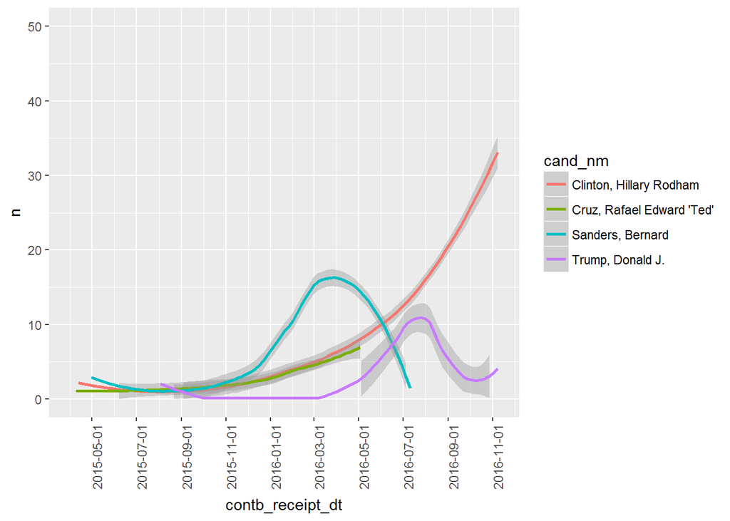

```r
sanders_nm <- 'Sanders, Bernard'
clinton_nm <- 'Clinton, Hillary Rodham'
trump_nm <- 'Trump, Donald J.'
cruz_nm <- "Cruz, Rafael Edward 'Ted'"

finalists <- us_samp.clean[which(us_samp.clean$cand_nm == sanders_nm |
                                      us_samp.clean$cand_nm == clinton_nm |
                                      us_samp.clean$cand_nm == trump_nm |
                                      us_samp.clean$cand_nm == cruz_nm), ]
#head(finalists)
finalists.by_date.nm <- finalists %>%
    group_by(contb_receipt_dt, cand_nm) %>%
    summarise(mean_contb = mean(contb_receipt_amt),
              median_contb = median(contb_receipt_amt),
              n = n()) %>%
    arrange(contb_receipt_dt, cand_nm)
#head(finalists.by_date.nm, 10)

cand_time <- ggplot(data = finalists.by_date.nm, aes(x = contb_receipt_dt, y = n, color = cand_nm))+
    geom_smooth() +
    scale_x_date(breaks = date_breaks("2 months"), limits = c(as.Date('2015-04-01'),as.Date('2016-11-08'))) +
    theme(axis.text.x = element_text(angle = 90))

cand_time + scale_y_continuous(limits = c(0,50))
```

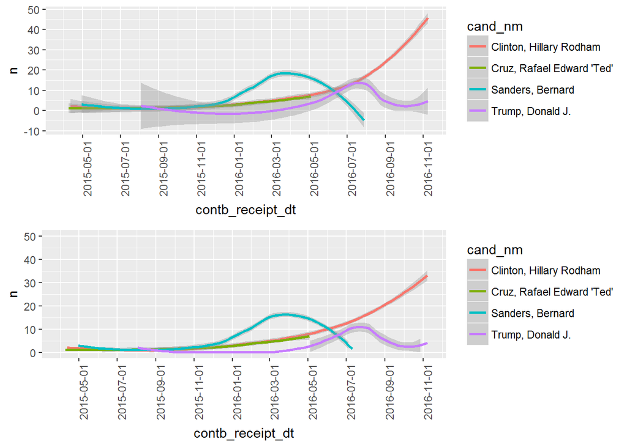

```r
grid.arrange(cand_time, cand_time + scale_y_continuous(limits = c(0,50)))
```

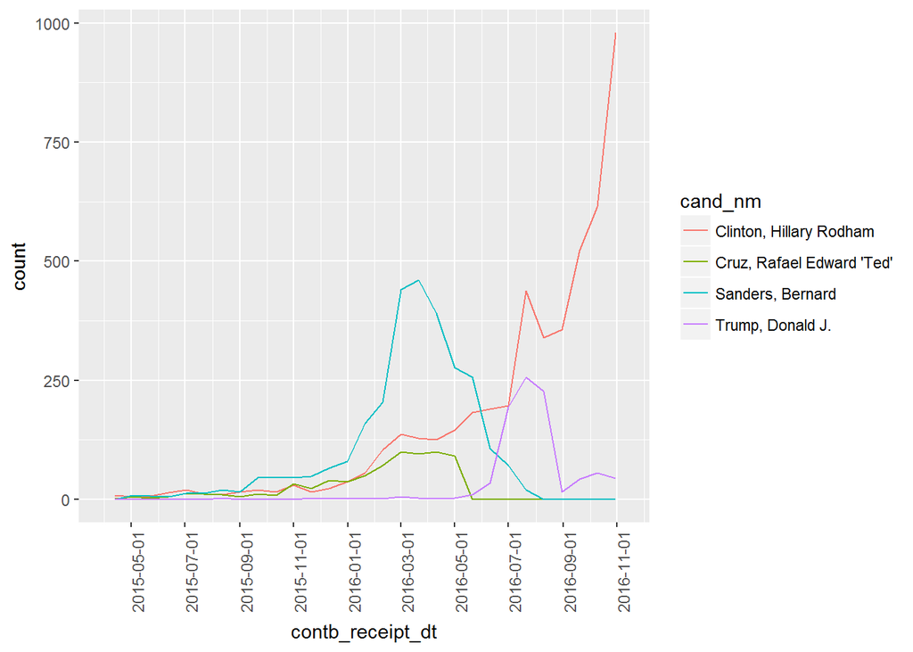

```r
#freqpoly
ggplot(data = finalists, aes(x = contb_receipt_dt, color = cand_nm))+
    geom_freqpoly() +
    scale_x_date(breaks = date_breaks("2 months"), limits = c(as.Date('2015-04-01'),as.Date('2016-11-08'))) +
    theme(axis.text.x = element_text(angle = 90))
```

Now that is a cool plot, BUT why does it go negative???

## Top candidates average donation size over time

Let’s see how average donation size varied over time for these candidates

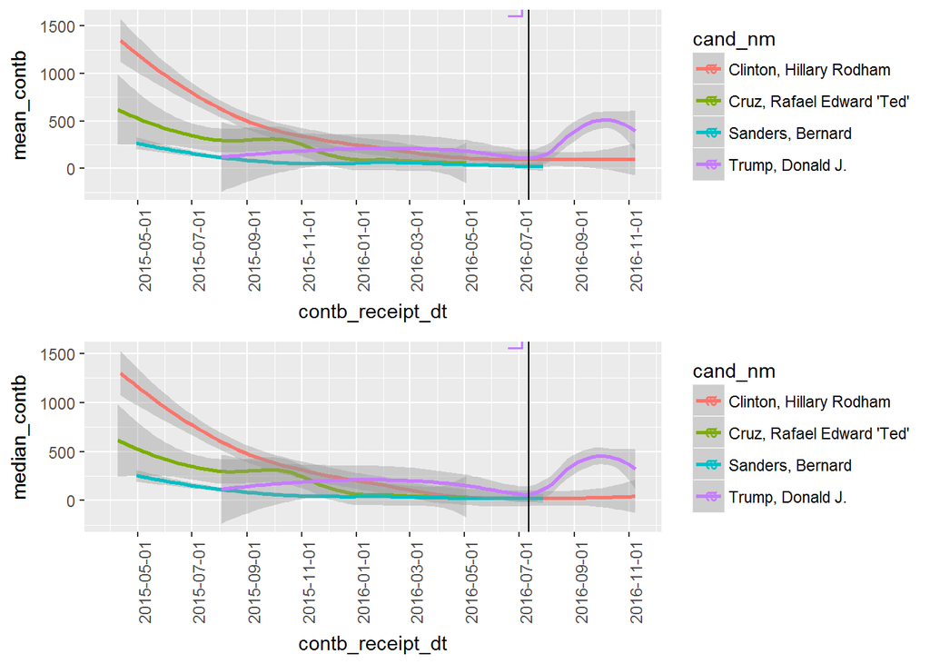

```r
# I want to add a line for the last primary candidate dropping out. Sanders apparent official dropout date was July 12th:
sanders_drop <- as.Date('2016-07-12')


mean_contb <- ggplot(data = finalists.by_date.nm, aes(x = contb_receipt_dt, y = mean_contb, color = cand_nm))+
    geom_smooth()+
    scale_x_date(breaks = date_breaks("2 months"), limits = c(as.Date('2015-04-01'),as.Date('2016-11-08'))) +
    theme(axis.text.x = element_text(angle = 90))+
    geom_vline(xintercept= as.numeric(sanders_drop))+
    geom_text(mapping = aes(x = sanders_drop, y = 0, label = 'Last primary candidate drops out'),
              size = 4, angle = 90, vjust=-0.4, hjust=-0.5)

median_contb <- ggplot(data = finalists.by_date.nm, aes(x = contb_receipt_dt, y = median_contb, color = cand_nm))+
    geom_smooth()+
    scale_x_date(breaks = date_breaks("2 months"), limits = c(as.Date('2015-04-01'),as.Date('2016-11-08'))) +
    theme(axis.text.x = element_text(angle = 90))+
    geom_vline(xintercept= as.numeric(sanders_drop))+
    geom_text(mapping = aes(x = sanders_drop, y = 0, label = 'Last primary candidate drops out'),
              size = 4, angle = 90, vjust=-0.4, hjust=-0.5)

grid.arrange(mean_contb, median_contb) # They're not too different, let's go with mean.
```

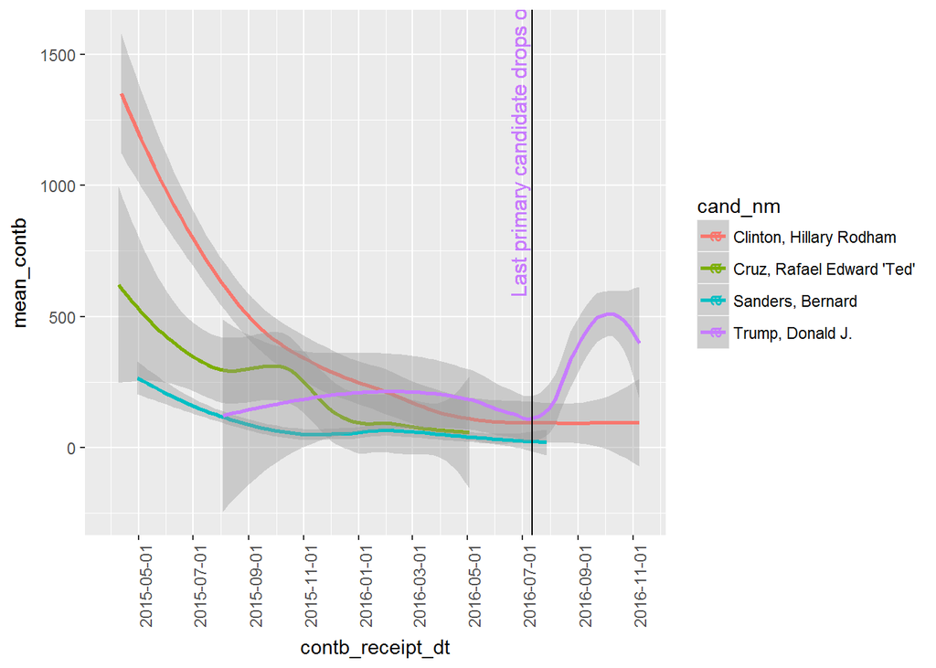

```r
mean_contb
```

I like that one, too. Clinton started off with some giant donations. Really interesting to see Trump’s mean contribution amount jump quite significantly once it was officially Clinton v. Trump from the major parties.

## Contributions by state

I want to look at number and size of contributions by state.

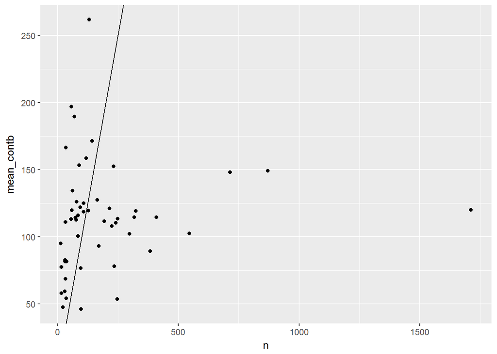

```r
#chain functions together
us_samp.by_state <- us_samp.clean %>%
    group_by(contbr_st) %>%
    summarise(mean_contb = mean(contb_receipt_amt),
              median_contb = median(contb_receipt_amt),
              n = n()) %>%
    arrange(contbr_st)
#View(us_samp.by_state)

# Merge with state population
us_samp.by_state1 <- merge(us_samp.by_state, pop.state, by = 'contbr_st')
#View(us_samp.by_state1)

us_samp.by_state1$nperhundthou <- us_samp.by_state1$n/us_samp.by_state1$pop.hundthou

# Let's plot number of contributions by average contribution
ggplot(aes(x = n, y = mean_contb), data = us_samp.by_state1) +
    geom_point()+
    geom_abline()
```

```r
with(us_samp.by_state1, cor(mean_contb, n))
```

```
## [1] 0.1184116
```

This last plot is somewhat interesting, but not really. There’s a weak positive correlation (0.11) between the number of contributions and the average size of donations in states. So very roughly, as more people contribute, the average contribution size goes up. This plot is most clustered around about 100 people giving in a state, at an average of about $120. That’s actually fairly high. Remembering that this is a sample, we can’t actually look at the number of contributions as meaningful, only the trends.

Let’s create a heat map of the US with average contribution sizes in bins by color.

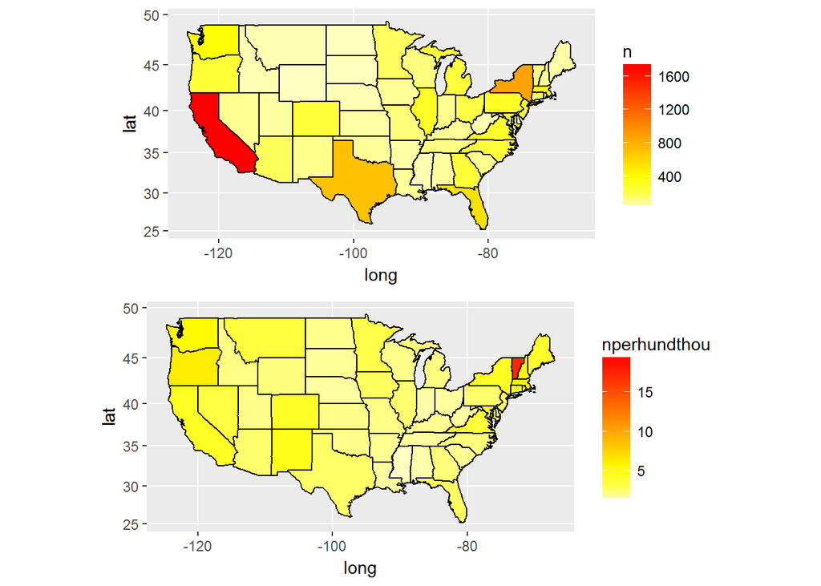

```r
#Source: http://stackoverflow.com/questions/24441775/how-do-you-create-a-us-states-heatmap-based-on-some-values
states <- map_data("state")
# create all lowercase state name to merge with map data
us_samp.by_state1$region <- tolower(us_samp.by_state1$State)

map.df <- merge(states, us_samp.by_state1, by='region', all.us_samp.by_state1 = T)

# Heat map by count of contributions
map_num <-ggplot(map.df, aes(x=long,y=lat,group=group))+
  geom_polygon(aes(fill=n))+
  geom_path()+
  scale_fill_gradientn(colours=rev(heat.colors(10)),na.value="grey90")+
  coord_map()

# Heat map by count of contributions per capita
map_numcap <- ggplot(map.df, aes(x=long,y=lat,group=group))+
  geom_polygon(aes(fill=nperhundthou))+
  geom_path()+
  scale_fill_gradientn(colours=rev(heat.colors(10)),na.value="grey90")+
  coord_map()

grid.arrange(map_num, map_numcap)
```

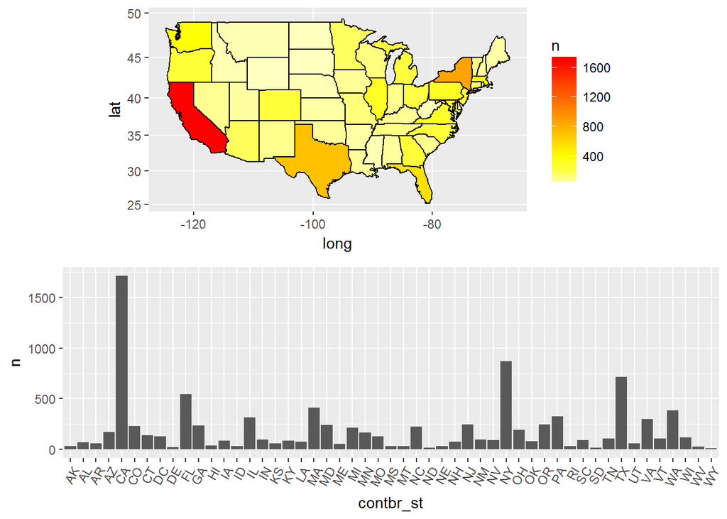

```r
# Bar charts
bar_num <- ggplot(data = us_samp.by_state1, aes(x = contbr_st, y = n))+
    geom_bar(stat = 'identity') +
    theme(axis.text.x = element_text(angle = 60, hjust = 1))

bar_numcap <- ggplot(data = us_samp.by_state1, aes(x = contbr_st, y = nperhundthou))+
    geom_bar(stat = 'identity') +
    theme(axis.text.x = element_text(angle = 60, hjust = 1))

# Numbers of contributions by state
grid.arrange(map_num, bar_num)
```

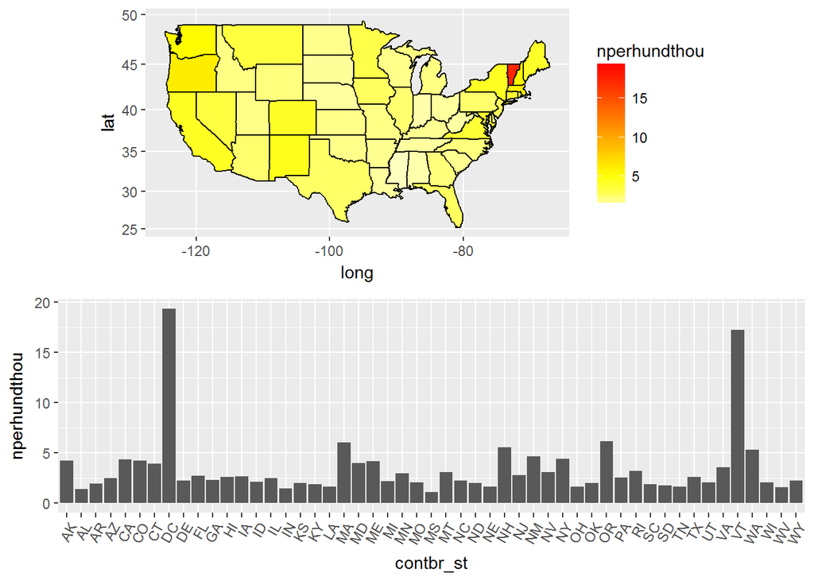

```r
# Numbers of contributions per hundred thousand population by state
grid.arrange(map_numcap, bar_numcap)
```

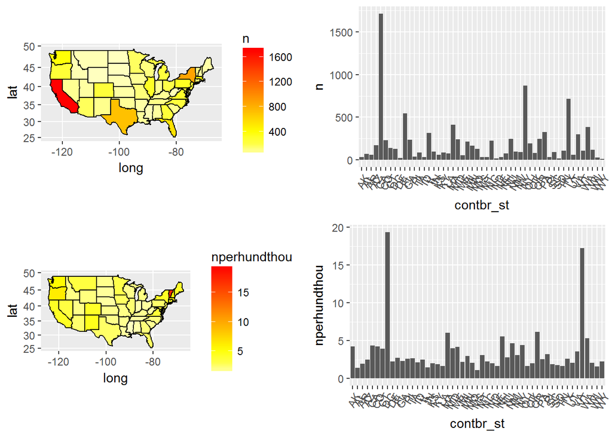

```r
#All of them!
grid.arrange(map_num, bar_num, map_numcap, bar_numcap)
```

The map of contributions per population doesn’t show much because Vermont (and DC which is too small to see) are so far out of the range of the other states that the rest are all light yellow.